# Cladosporium experiment 1

Devin R. Leopold

21 November, 2021

```r
library(tidyverse)
library(magrittr)
library(treeio)
library(ape)
library(brms)
library(bayestestR)
library(emmeans)

# Source custom functions
sourced <- list.files("src", full.names = T) %>% lapply(source)

#Import raw data
dat <- read.csv("data/clad_rawcounts.csv") %>%
  mutate(id=gsub("_","",culture))

#Import phylogenetic tree
tree <- read.newick("data/clad_multigene.tre") %>%
  keep.tip(unique(dat$id))
tree$node.label %<>% gsub(".0","",., fixed = T)

#Summarise data by isolate
dat.iso <- dat %>% group_by(id, species, clade, region) %>%
  summarise(rust=sum(disease_severity),
            rust.perdisk=sum(disease_severity)/n(),
            mycoparasitism=sum(mycoparasitism),
            mycoparasitism.perdisk=sum(mycoparasitism)/n(),
            n=n(), .groups='keep')
```

# Visualize phylogenetic patterns for rust disease severity and mycoparasitism

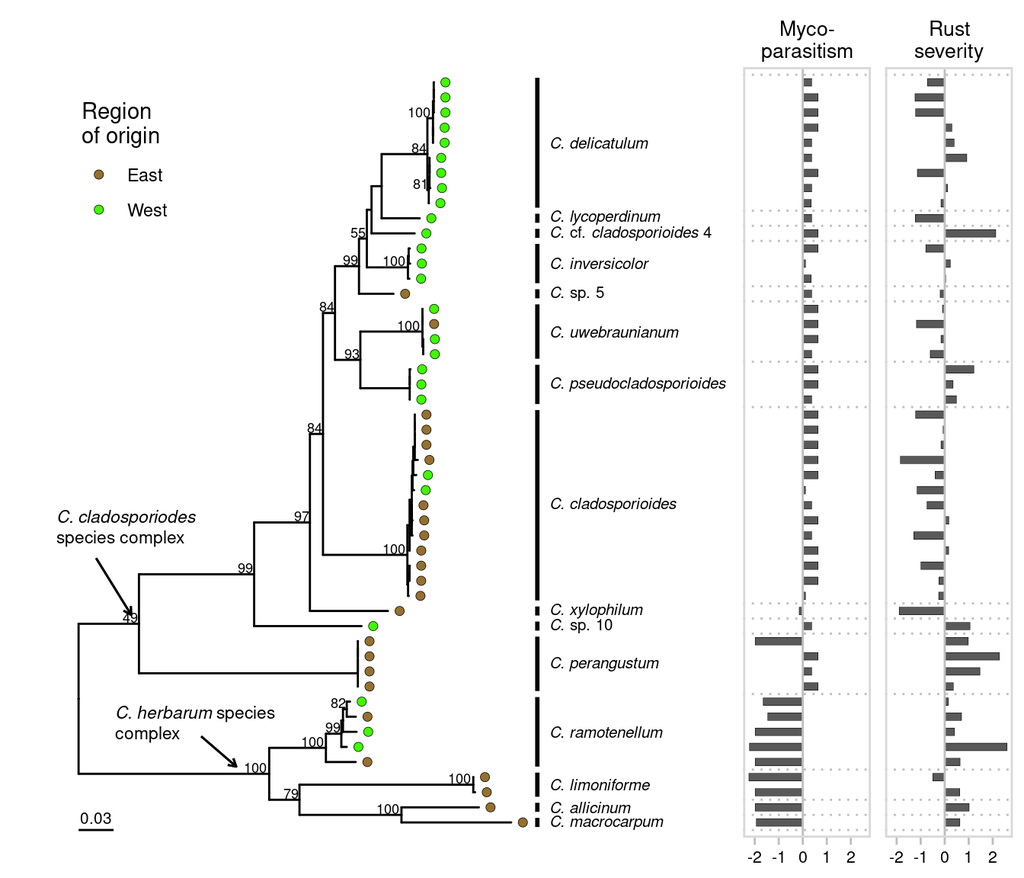

# Test for phylogenetic signal

Using [Blomberg’s *K*](https://onlinelibrary.wiley.com/doi/10.1111/j.0014-3820.2003.tb00285.x) with permutation test implemented in R-package [phylosignal](https://www.ncbi.nlm.nih.gov/pmc/articles/PMC4799788/). For this test we will use the mean values for each species .

```r
# Get species means
dat.spp <- dat.iso %>%
  mutate(region=region=="East") %>%
  group_by(species) %>%
  summarise(Rust_severity=sum(rust.perdisk)/n(),
            Mycoparasitism=sum(mycoparasitism.perdisk)/n(),
            region=mean(region),
            id=id[1], .groups = 'drop') %>%
  #mutate(region=as.numeric(as.factor(region))) %>%
  dplyr::select(-species) %>%
  column_to_rownames("id")
# Subset tree to one representative per species
tree.spp <- tree %>%
  keep.tip(rownames(dat.spp))
# Make combined tree/data object for analysis
p4d <- phylobase::phylo4d(tree.spp, dat.spp)

# Run test for phylogenetic signal using Blomberg's K
phylo.spp <- phylosignal::phyloSignal(p4d = p4d, method = "K", reps=1999)
tibble(response=rownames(phylo.spp$stat),
       K=phylo.spp$stat$K,
       p=phylo.spp$pvalue$K)
```

```
## # A tibble: 3 × 3
##   response           K      p
##   <chr>          <dbl>  <dbl>
## 1 Rust_severity  0.345 0.534
## 2 Mycoparasitism 4.38  0.0005
## 3 region         0.454 0.118
```

The figure above suggests that the high *K* value for mycoparasitism is largely due to the difference between the *C. cladosporiodes* species complex and the *C. herbarum* species complex. This pattern is even more clear in a boxplot showing the mean values for each species within each species complex.

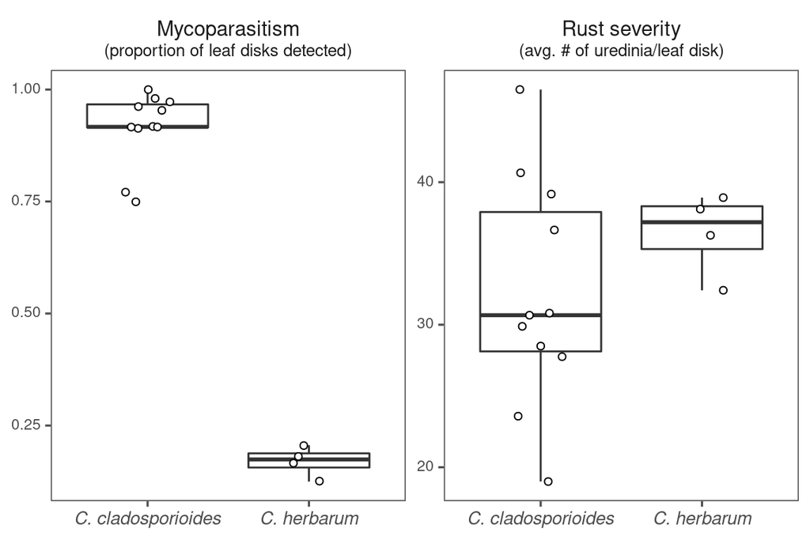

# Phylogenetic regression

In order to test the significance of the patterns observed across the entire data set above we need to account for the non-independence of species across the phylogenetic tree and the inclusion of multiple replicates of each isolate. In addition, we need to account for possible correlation of leaf disks co-occuring on the same plate during the experiment. In order to fit this type of phylogenetic mixed-model we will take a flexible Bayesian approach using the R-package [brms](https://paul-buerkner.github.io/brms/) and [baytestR](https://easystats.github.io/bayestestR/).

## Rust severity

First we will fit a model of rust severity, where the count of rust uredinia on a leaf disk is the response in a phylogenetic glmm with a negative binomial error distribution. Additional random intercept terms are included for isolate and plate.

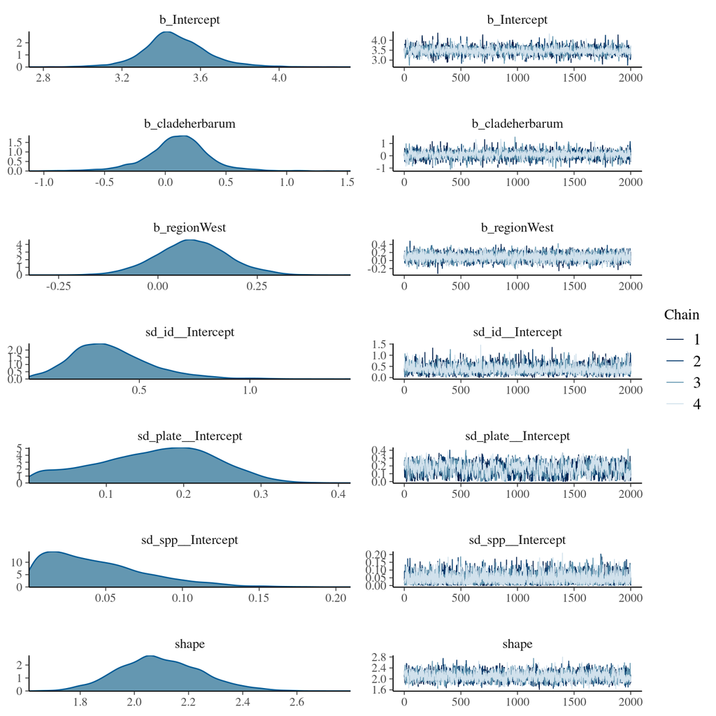

```r
#duplicate isolate id column to allow a separate random effects term for repeated measures
dat$spp <- dat$id
#get variance-covariance matrix from tree
A <- ape::vcv.phylo(tree)

model_rust <- brm(
  disease_severity ~ clade + region +
    (1|plate) + (1|spp) +
    (1|gr(id, cov = A)),
  data = dat,
  family = negbinomial(),
  data2 = list(A = A),
  chains = 4, cores = 4, iter = 4000,
  control = list(adapt_delta = 0.995),
  prior=prior(cauchy(0, 2.5), class='b'),
  sample_prior = T,
  save_pars = save_pars(all = TRUE),
  silent = 2, refresh = 0,
  seed = 80
)
plot(model_rust, N=7)
```

We can validate the model by comparing simulated data from the model to the observed data (ie posterior predictive checks).

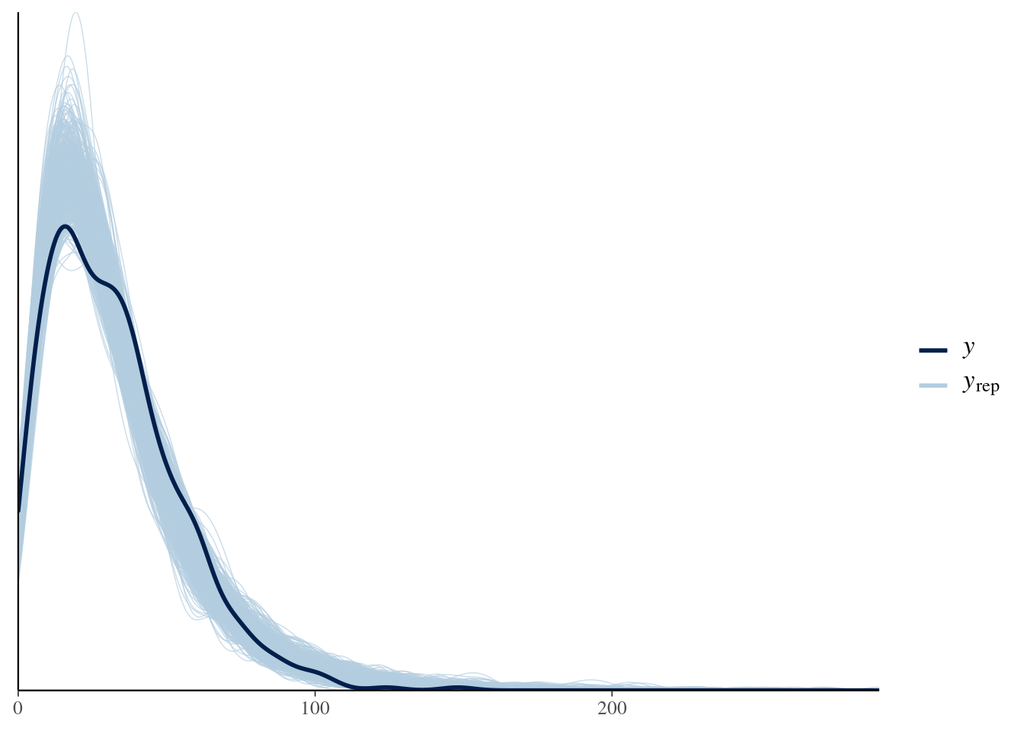

```r
pp_check(model_rust, ndraws = 500)
```

We can also check for overly influential data points using Pareto-smoothed importance sampling (PSIS).

```r
(loo_rust <- loo(model_rust, cores=parallel::detectCores(), moment_match = TRUE))
```

```
##
## Computed from 8000 by 591 log-likelihood matrix
##
##          Estimate   SE
## elpd_loo  -2588.2 17.4
## p_loo        34.5  2.0
## looic      5176.4 34.8
## ------
## Monte Carlo SE of elpd_loo is 0.1.
##
## Pareto k diagnostic values:
##                          Count Pct.    Min. n_eff
## (-Inf, 0.5]   (good)     587   99.3%   1209
##  (0.5, 0.7]   (ok)         4    0.7%   1381
##    (0.7, 1]   (bad)        0    0.0%   <NA>
##    (1, Inf)   (very bad)   0    0.0%   <NA>
##
## All Pareto k estimates are ok (k < 0.7).
## See help('pareto-k-diagnostic') for details.
```

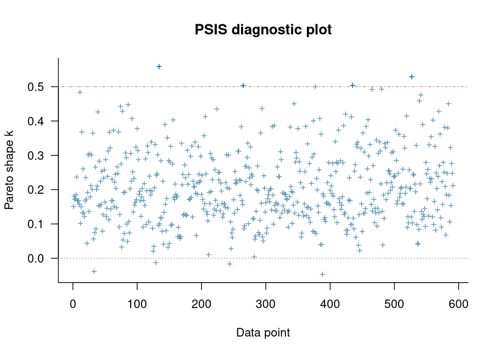

```r
plot(loo_rust)
```

Finally, we can examine the evidence for our (fixed) effects of interest from the posterior distribution

```r
post_rust <- describe_posterior(model_rust, test = "bf" , ci=0.89) %>%
  data.frame
```

```
## Sampling priors, please wait...
```

```r
pander::pander(post_rust, digits=2)
```

|  | Parameter | Median | CI | CI_low | CI_high | log_BF | Rhat | ESS |
| --- | --- | --- | --- | --- | --- | --- | --- | --- |
| **2** | b_Intercept | 3.5 | 0.89 | 3.2 | 3.7 | 30 | 1 | 2577 |
| **1** | b_cladeherbarum | 0.11 | 0.89 | -0.33 | 0.47 | -2.6 | 1 | 3070 |
| **3** | b_regionWest | 0.086 | 0.89 | -0.06 | 0.23 | -3 | 1 | 6028 |
| **4** | prior_shape | NA | NA | NA | NA | NA | 1 | 7789 |

## Mycoparasitism

Because mycoparasitism was measured as presence / absence on each leaf disk, we will fit a similar model using a binomial distribution. In addition, because our measure of mycoparasitism depends on the presence of uredinia (more uredinia means more opportunities to detect mycoparasitism) we will also include the number of uredinia as a fixed effect in the model.

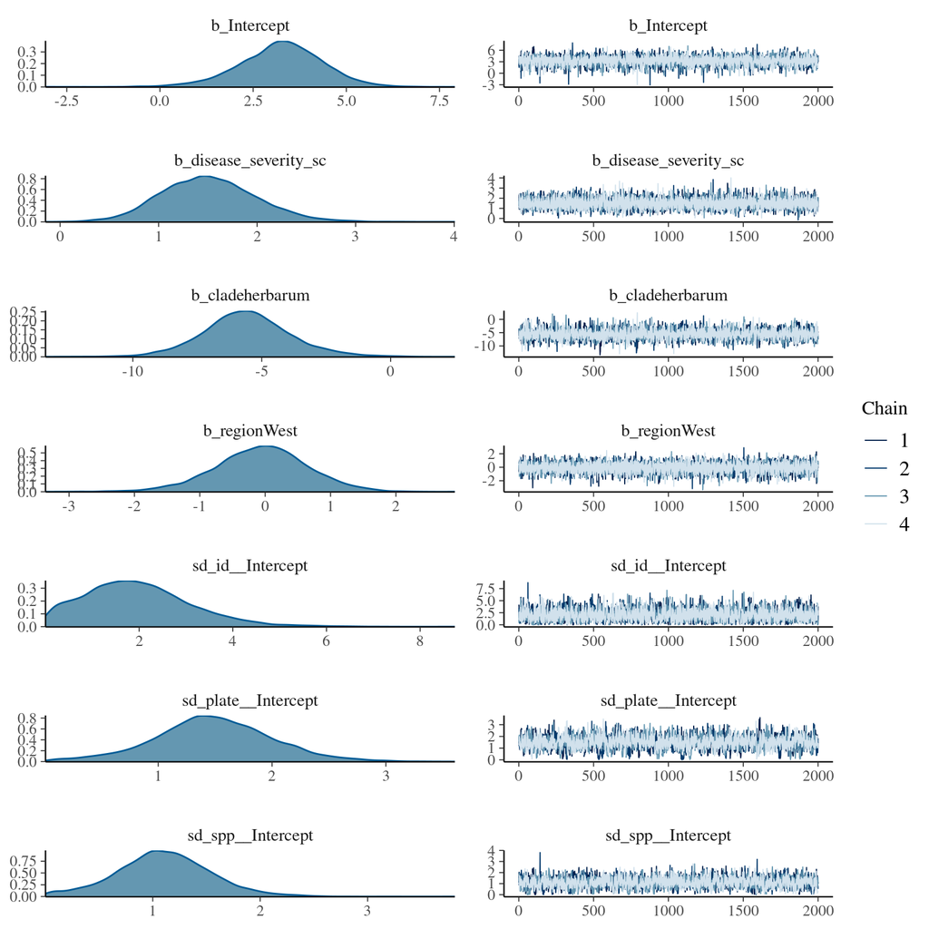

```r
#scale disease severity to mean 0 and sd = 0.5
dat %<>%
  mutate(
    disease_severity_sc = scale(disease_severity, scale=sd(disease_severity)*2)
  )

model_myco <- brm(
  mycoparasitism ~ disease_severity_sc + clade + region +
    (1|plate) + (1|spp) +
    (1|gr(id, cov = A)),
  data = dat,
  family = bernoulli(),
  data2 = list(A = A),
  chains = 4, cores = 4, iter = 4000,
  control = list(adapt_delta = 0.995),
  prior=prior(cauchy(0, 5), class='b'),
  sample_prior = T,
  save_pars = save_pars(all = TRUE),
  silent = 2, refresh = 0,
  seed=80
)
plot(model_myco, N=7)
```

Visual check of model fit using data simulated from the posterior distribution

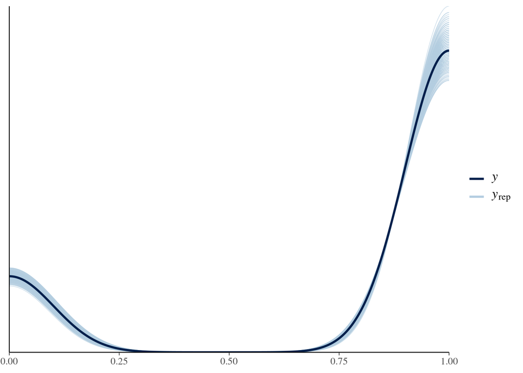

```r
pp_check(model_myco, ndraws=500)
```

Check for overly influential data points using Pareto-smoothed importance sampling (PSIS).

```r
(loo_rust <- loo(model_myco, cores=parallel::detectCores(), moment_match = TRUE))
```

```
##
## Computed from 8000 by 591 log-likelihood matrix
##
##          Estimate   SE
## elpd_loo   -150.9 15.7
## p_loo        53.0  6.7
## looic       301.8 31.4
## ------
## Monte Carlo SE of elpd_loo is 0.2.
##
## Pareto k diagnostic values:
##                          Count Pct.    Min. n_eff
## (-Inf, 0.5]   (good)     555   93.9%   1027
##  (0.5, 0.7]   (ok)        36    6.1%   265
##    (0.7, 1]   (bad)        0    0.0%   <NA>
##    (1, Inf)   (very bad)   0    0.0%   <NA>
##
## All Pareto k estimates are ok (k < 0.7).
## See help('pareto-k-diagnostic') for details.
```

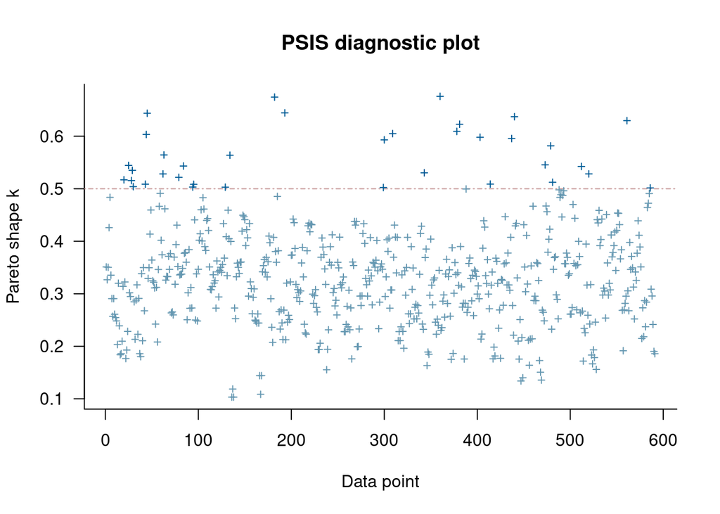

```r
plot(loo_rust)
```

Finally, we can examine the evidence for our (fixed) effects of interest from the posterior distribution

```r
post_myco <- describe_posterior(model_myco, test = "bf" , ci=0.89) %>%
  data.frame
```

```
## Sampling priors, please wait...
```

```r
pander::pander(post_myco, digits=2)
```

Table continues below

|  | Parameter | Median | CI | CI_low | CI_high | log_BF |
| --- | --- | --- | --- | --- | --- | --- |
| **3** | b_Intercept | 3.3 | 0.89 | 1.5 | 5 | 2 |
| **2** | b_disease_severity_sc | 1.5 | 0.89 | 0.77 | 2.3 | 2.7 |
| **1** | b_cladeherbarum | -5.6 | 0.89 | -8.3 | -2.8 | 2.8 |
| **4** | b_regionWest | -0.039 | 0.89 | -1.2 | 1.1 | -2.3 |

|  | Rhat | ESS |
| --- | --- | --- |
| **3** | 1 | 3531 |
| **2** | 1 | 5508 |
| **1** | 1 | 3604 |
| **4** | 1 | 6199 |

### Summary of mycoparasitism model results

We found no evidence (BF = 0.1) that *Cladosporium* isolates differed, on average, in their likelihood of displaying a mycoparasitism phenotype based on whether they originated from east (0.62; 89% HDI: 0.35-0.89) or west (0.62; 89% HDI: 0.29-0.88) of the Cascades.

We did find evidence that *Cladosporium* isolates from different species complexes different in their likelihood of being mycoparasitic (BF = 17.24). Specifically, the predicted probability of observing mycoparasitism in *C. herbarum* isolates was 0.09 (89% HDI: 0-0.27), while the probability of observing mycoparasitism in *C. cladosporioides* isolates was 0.96 (89% HDI: 0.87-1).